# Olist

## Introduction

This is a Brazilian ecommerce public dataset of orders made at Olist Store. The dataset has information of 100k orders from 2016 to 2018 made at multiple marketplaces in Brazil. Its features allows viewing an order from multiple dimensions: from order status, price, payment and freight performance to customer location, product attributes and finally reviews written by customers. We also released a geolocation dataset that relates Brazilian zip codes to lat/lng coordinates.

This is real commercial data, it has been anonymised, and references to the companies and partners in the review text have been replaced with the names of Game of Thrones great houses.

## Business Model

This dataset was generously provided by Olist, the largest department store in Brazilian marketplaces. Olist connects small businesses from all over Brazil to channels without hassle and with a single contract. Those merchants are able to sell their products through the Olist Store and ship them directly to the customers using Olist logistics partners.

After a customer purchases the product from Olist Store a seller gets notified to fulfill that order. Once the customer receives the product, or the estimated delivery date is due, the customer gets a satisfaction survey by email where he can give a note for the purchase experience and write down some comments.

An order might have multiple items. Each item might be fulfilled by a distinct seller. All text identifying stores and partners where replaced by the names of Game of Thrones great houses.

## Data Schema

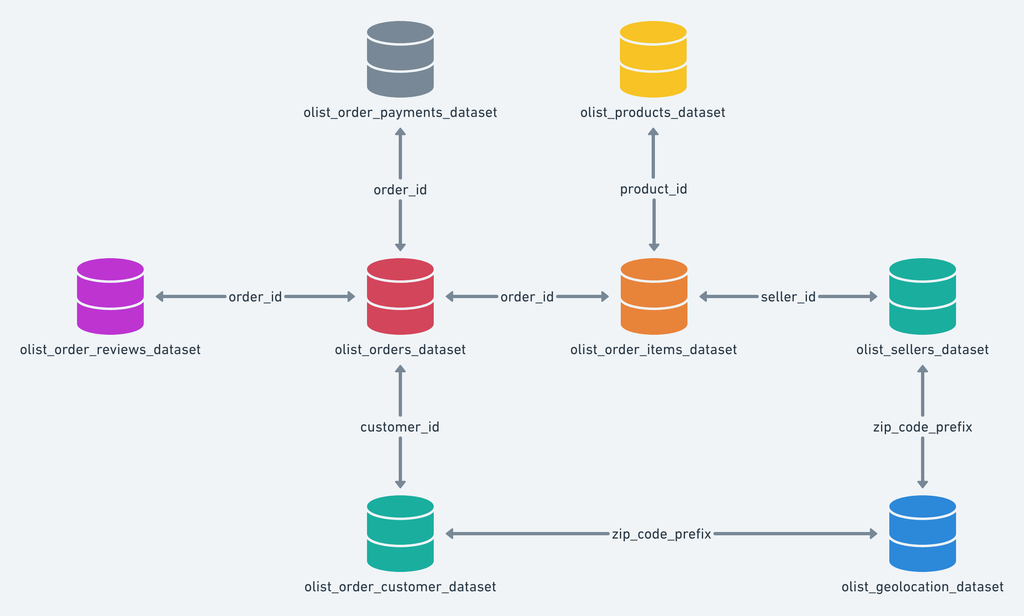

# Challenge

Focus is to explore the dataset and derive recommended actions for Olist.

# Explorative analysis of customer data

```python
#Having a first glance at the customer data and structure
customer_data.head()
```

|  | customer_id | customer_unique_id | customer_zip_code_prefix | customer_city | customer_state |
| --- | --- | --- | --- | --- | --- |
| 0 | 06b8999e2fba1a1fbc88172c00ba8bc7 | 861eff4711a542e4b93843c6dd7febb0 | 14409 | franca | SP |
| 1 | 18955e83d337fd6b2def6b18a428ac77 | 290c77bc529b7ac935b93aa66c333dc3 | 9790 | sao bernardo do campo | SP |
| 2 | 4e7b3e00288586ebd08712fdd0374a03 | 060e732b5b29e8181a18229c7b0b2b5e | 1151 | sao paulo | SP |
| 3 | b2b6027bc5c5109e529d4dc6358b12c3 | 259dac757896d24d7702b9acbbff3f3c | 8775 | mogi das cruzes | SP |
| 4 | 4f2d8ab171c80ec8364f7c12e35b23ad | 345ecd01c38d18a9036ed96c73b8d066 | 13056 | campinas | SP |

```python
#Checking if entries if any entries are missing and datatype of each column.
customer_data.info()
```

```
<class 'pandas.core.frame.DataFrame'>
RangeIndex: 99441 entries, 0 to 99440
Data columns (total 5 columns):
 #   Column                    Non-Null Count  Dtype
---  ------                    --------------  -----
 0   customer_id               99441 non-null  object
 1   customer_unique_id        99441 non-null  object
 2   customer_zip_code_prefix  99441 non-null  int64
 3   customer_city             99441 non-null  object
 4   customer_state            99441 non-null  object
dtypes: int64(1), object(4)
memory usage: 3.8+ MB
```

```python
customer_data.isna().sum()
```

```
customer_id                 0
customer_unique_id          0
customer_zip_code_prefix    0
customer_city               0
customer_state              0
dtype: int64
```

```python
customer_geoloc_merge
```

|  | customer_city | customer_count | geolocation_lat | geolocation_lng |
| --- | --- | --- | --- | --- |
| 0 | sao paulo | 15540 | -23.563625 | -46.649844 |
| 1 | rio de janeiro | 6882 | -22.914532 | -43.272798 |
| 2 | belo horizonte | 2773 | -19.919393 | -43.952598 |
| 3 | brasilia | 2131 | -15.817813 | -47.937957 |
| 4 | curitiba | 1521 | -25.445220 | -49.273492 |
| ... | ... | ... | ... | ... |
| 4114 | ibiara | 1 | -7.504601 | -38.408086 |
| 4115 | rio espera | 1 | -20.857818 | -43.475242 |
| 4116 | rio dos indios | 1 | -27.304968 | -52.841975 |
| 4117 | rio dos cedros | 1 | -26.741208 | -49.274295 |
| 4118 | lagoao | 1 | -29.227112 | -52.776003 |

4119 rows × 4 columns

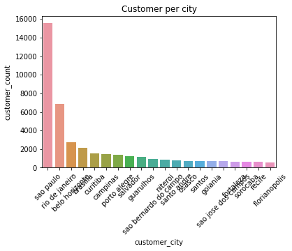

```python
plt.title('Customer per city')
plt.xticks(rotation = 45)
sns.barplot(data=customer_geoloc_merge[:20], x='customer_city', y='customer_count');
```

```python
#Visualizing on a map the distribution of customers across South America
px.scatter_geo(customer_geoloc_merge,
               lat='geolocation_lat',
               lon='geolocation_lng',
               size='customer_count',
               #color='customer_count',
               scope='south america')
```

[interactive chart not shown]

# Investigate what's driving low reviews

As Olist is facing consumers as the onlineshop and not the small sellers, any hit in reputation is negatively affecting Olist's business. This means any bad reviews from customers will lead to Olist's customer rating at Amazon and other marketplaces will go down, decreasing the likelyhood of customers buying at olist.

Let's investigate what is driving the low ratings.

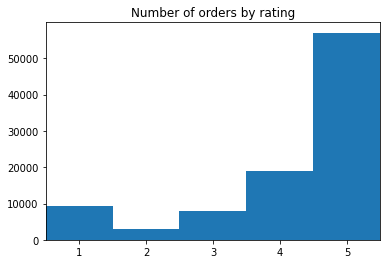

```python
plt.xlim([0.5,5.5])
plt.title('Number of orders by rating')
plt.hist(x=order_data.review_score, bins=np.arange(7)-0.5);
```

```python
np.sum(order_data.review_score <= 3)/len(order_data)
```

```
0.2107562815895717
```

Over 21% of reviews have a score of 3 and below, which is major cost for Olist. Reducing the drivers for negative reviews will positive impact overall business performance

## Delivery time/delay as explanation for low reviews

### Correlations

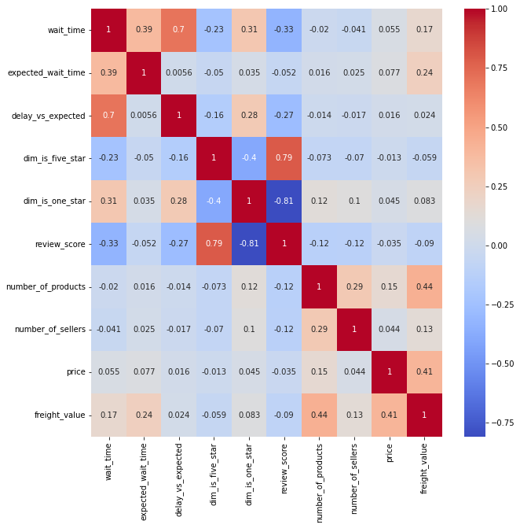

```python
plt.figure(figsize=(10,10))

sns.heatmap(order_data.corr(),
            cmap='coolwarm',
            annot = True,
            annot_kws={"size": 10})
```

Based on above's heatmap, the wait time and delay vs expected has a medium correlation with the negative review score. Wait time corr: -0.33 Delay vs. expected: -0.27

### Explanatory power of delay vs expected and wait time for review score

```python
#Importing statsmodel and check for a linear regression how much of review score's variance is explained by
#i) delay vs. expected and ii) wait time
import statsmodels.formula.api as smf
```

### Univariate regression with delay vs expected

```python
smf.ols(formula = 'review_score ~ delay_vs_expected', data=order_data).fit().summary()
```

OLS Regression Results

| Dep. Variable: | review_score | R-squared: | 0.074 |
| --- | --- | --- | --- |
| Model: | OLS | Adj. R-squared: | 0.074 |
| Method: | Least Squares | F-statistic: | 7715. |
| Date: | Fri, 15 Jul 2022 | Prob (F-statistic): | 0.00 |
| Time: | 13:31:31 | Log-Likelihood: | -1.5717e+05 |
| No. Observations: | 96353 | AIC: | 3.143e+05 |
| Df Residuals: | 96351 | BIC: | 3.144e+05 |
| Df Model: | 1 |  |  |
| Covariance Type: | nonrobust |  |  |

|  | coef | std err | t | P>\|t\| | [0.025 | 0.975] |
| --- | --- | --- | --- | --- | --- | --- |
| Intercept | 4.2124 | 0.004 | 1043.898 | 0.000 | 4.205 | 4.220 |
| delay_vs_expected | -0.0751 | 0.001 | -87.836 | 0.000 | -0.077 | -0.073 |

| Omnibus: | 20752.916 | Durbin-Watson: | 2.004 |
| --- | --- | --- | --- |
| Prob(Omnibus): | 0.000 | Jarque-Bera (JB): | 49852.017 |
| Skew: | -1.204 | Prob(JB): | 0.00 |
| Kurtosis: | 5.573 | Cond. No. | 4.78 |

Notes:  
[1] Standard Errors assume that the covariance matrix of the errors is correctly specified.

### Univariate regression with wait_time

```python
smf.ols(formula = 'review_score ~ wait_time', data=order_data).fit().summary()
```

OLS Regression Results

| Dep. Variable: | review_score | R-squared: | 0.111 |
| --- | --- | --- | --- |
| Model: | OLS | Adj. R-squared: | 0.111 |
| Method: | Least Squares | F-statistic: | 1.208e+04 |
| Date: | Fri, 15 Jul 2022 | Prob (F-statistic): | 0.00 |
| Time: | 13:31:31 | Log-Likelihood: | -1.5519e+05 |
| No. Observations: | 96353 | AIC: | 3.104e+05 |
| Df Residuals: | 96351 | BIC: | 3.104e+05 |
| Df Model: | 1 |  |  |
| Covariance Type: | nonrobust |  |  |

|  | coef | std err | t | P>\|t\| | [0.025 | 0.975] |
| --- | --- | --- | --- | --- | --- | --- |
| Intercept | 4.7236 | 0.006 | 729.482 | 0.000 | 4.711 | 4.736 |
| wait_time | -0.0453 | 0.000 | -109.902 | 0.000 | -0.046 | -0.045 |

| Omnibus: | 19639.914 | Durbin-Watson: | 2.007 |
| --- | --- | --- | --- |
| Prob(Omnibus): | 0.000 | Jarque-Bera (JB): | 35586.515 |
| Skew: | -1.300 | Prob(JB): | 0.00 |
| Kurtosis: | 4.449 | Cond. No. | 26.1 |

Notes:  
[1] Standard Errors assume that the covariance matrix of the errors is correctly specified.

### Multivariate regression with delay_vs_expected and wait_time as features

```python
smf.ols(formula = 'review_score ~ delay_vs_expected + wait_time', data=order_data).fit().summary()
```

OLS Regression Results

| Dep. Variable: | review_score | R-squared: | 0.114 |
| --- | --- | --- | --- |
| Model: | OLS | Adj. R-squared: | 0.114 |
| Method: | Least Squares | F-statistic: | 6211. |
| Date: | Fri, 15 Jul 2022 | Prob (F-statistic): | 0.00 |
| Time: | 13:31:31 | Log-Likelihood: | -1.5504e+05 |
| No. Observations: | 96353 | AIC: | 3.101e+05 |
| Df Residuals: | 96350 | BIC: | 3.101e+05 |
| Df Model: | 2 |  |  |
| Covariance Type: | nonrobust |  |  |

|  | coef | std err | t | P>\|t\| | [0.025 | 0.975] |
| --- | --- | --- | --- | --- | --- | --- |
| Intercept | 4.6500 | 0.008 | 602.765 | 0.000 | 4.635 | 4.665 |
| delay_vs_expected | -0.0206 | 0.001 | -17.485 | 0.000 | -0.023 | -0.018 |
| wait_time | -0.0382 | 0.001 | -66.018 | 0.000 | -0.039 | -0.037 |

| Omnibus: | 20080.290 | Durbin-Watson: | 2.006 |
| --- | --- | --- | --- |
| Prob(Omnibus): | 0.000 | Jarque-Bera (JB): | 40618.500 |
| Skew: | -1.249 | Prob(JB): | 0.00 |
| Kurtosis: | 4.970 | Cond. No. | 31.7 |

Notes:  
[1] Standard Errors assume that the covariance matrix of the errors is correctly specified.

👉 Even with both wait_time and delay_vs_expected as features, the explanatory power (R-squared) is low. This means there must be a different driver for low reviews

### Multivariate regression with all features

To ensure the features with larger scales are not shown to have much higher importance than lower scaled features, we normalize the values.

```python
#Normalizing values for multivariate regression.

orders_norm = order_data.copy()
features = ["wait_time", "expected_wait_time","delay_vs_expected", "number_of_products", "number_of_sellers","price", "freight_value"]
orders_norm[features] = orders_norm[features].apply(lambda x: (x-x.mean())/ x.std(), axis=0)
orders_norm
```

|  | order_id | wait_time | expected_wait_time | delay_vs_expected | order_status | dim_is_five_star | dim_is_one_star | review_score | number_of_products | number_of_sellers | price | freight_value |
| --- | --- | --- | --- | --- | --- | --- | --- | --- | --- | --- | --- | --- |
| 0 | e481f51cbdc54678b7cc49136f2d6af7 | -0.432084 | -0.935929 | -0.162119 | delivered | 0 | 0 | 4 | -0.264657 | -0.112588 | -0.514185 | -0.653042 |
| 1 | 53cdb2fc8bc7dce0b6741e2150273451 | 0.133144 | -0.525643 | -0.162119 | delivered | 0 | 0 | 4 | -0.264657 | -0.112588 | -0.086552 | 0.000102 |
| 2 | 47770eb9100c2d0c44946d9cf07ec65d | -0.330823 | 0.330839 | -0.162119 | delivered | 1 | 0 | 5 | -0.264657 | -0.112588 | 0.112056 | -0.164580 |
| 3 | 949d5b44dbf5de918fe9c16f97b45f8a | 0.072525 | 0.279362 | -0.162119 | delivered | 1 | 0 | 5 | -0.264657 | -0.112588 | -0.441828 | 0.206652 |
| 4 | ad21c59c0840e6cb83a9ceb5573f8159 | -1.020282 | -1.327755 | -0.162119 | delivered | 1 | 0 | 5 | -0.264657 | -0.112588 | -0.562825 | -0.653042 |
| ... | ... | ... | ... | ... | ... | ... | ... | ... | ... | ... | ... | ... |
| 96356 | 9c5dedf39a927c1b2549525ed64a053c | -0.455195 | -0.588472 | -0.162119 | delivered | 1 | 0 | 5 | -0.264657 | -0.112588 | -0.311673 | -0.450214 |
| 96357 | 63943bddc261676b46f01ca7ac2f7bd8 | 1.022594 | -0.032290 | -0.162119 | delivered | 0 | 0 | 4 | -0.264657 | -0.112588 | 0.184365 | -0.123642 |
| 96358 | 83c1379a015df1e13d02aae0204711ab | 1.304464 | 0.758343 | -0.162119 | delivered | 1 | 0 | 5 | -0.264657 | -0.112588 | 0.334236 | 1.966047 |
| 96359 | 11c177c8e97725db2631073c19f07b62 | 0.482549 | 1.525669 | -0.162119 | delivered | 0 | 0 | 2 | 1.603238 | -0.112588 | 1.076557 | 2.717815 |
| 96360 | 66dea50a8b16d9b4dee7af250b4be1a5 | -0.512686 | 0.158106 | -0.162119 | delivered | 1 | 0 | 5 | -0.264657 | -0.112588 | -0.328545 | -0.204587 |

96353 rows × 12 columns

```python
model = smf.ols(formula = f"review_score ~ {' + '.join(features)}", data=orders_norm).fit()
model.summary()
```

OLS Regression Results

| Dep. Variable: | review_score | R-squared: | 0.146 |
| --- | --- | --- | --- |
| Model: | OLS | Adj. R-squared: | 0.146 |
| Method: | Least Squares | F-statistic: | 2357. |
| Date: | Fri, 15 Jul 2022 | Prob (F-statistic): | 0.00 |
| Time: | 13:31:32 | Log-Likelihood: | -1.5326e+05 |
| No. Observations: | 96353 | AIC: | 3.065e+05 |
| Df Residuals: | 96345 | BIC: | 3.066e+05 |
| Df Model: | 7 |  |  |
| Covariance Type: | nonrobust |  |  |

|  | coef | std err | t | P>\|t\| | [0.025 | 0.975] |
| --- | --- | --- | --- | --- | --- | --- |
| Intercept | 4.1557 | 0.004 | 1086.411 | 0.000 | 4.148 | 4.163 |
| wait_time | -0.4613 | 0.006 | -71.646 | 0.000 | -0.474 | -0.449 |
| expected_wait_time | 0.1128 | 0.005 | 24.545 | 0.000 | 0.104 | 0.122 |
| delay_vs_expected | -0.0308 | 0.006 | -5.221 | 0.000 | -0.042 | -0.019 |
| number_of_products | -0.1373 | 0.004 | -30.902 | 0.000 | -0.146 | -0.129 |
| number_of_sellers | -0.1347 | 0.004 | -33.647 | 0.000 | -0.143 | -0.127 |
| price | -0.0070 | 0.004 | -1.678 | 0.093 | -0.015 | 0.001 |
| freight_value | 0.0163 | 0.005 | 3.393 | 0.001 | 0.007 | 0.026 |

| Omnibus: | 18852.868 | Durbin-Watson: | 2.008 |
| --- | --- | --- | --- |
| Prob(Omnibus): | 0.000 | Jarque-Bera (JB): | 37213.061 |
| Skew: | -1.187 | Prob(JB): | 0.00 |
| Kurtosis: | 4.905 | Cond. No. | 3.15 |

Notes:  
[1] Standard Errors assume that the covariance matrix of the errors is correctly specified.

The currently included features still only have a low explanatory power with R-squared at 14.6%, **thus other features not included so far must be more important.**

```
(0.0, 5.5)
```

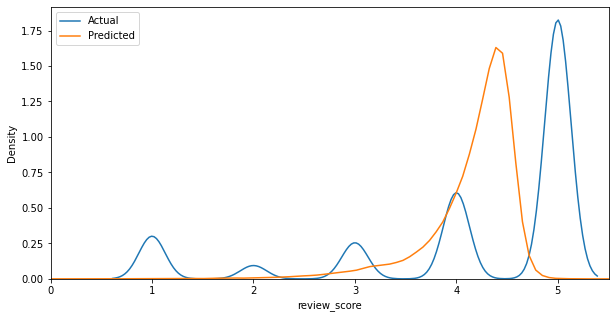

```python
plt.figure(figsize=(10,5))
sns.kdeplot(orders_norm["review_score"], label="Actual")
sns.kdeplot(predicted_revscore, label="Predicted")
plt.legend()
plt.xlim(0,5.5)
```

KDE plot confirms that the model's prediction are far off from the actual results -> This means that delivery time and delivery delays are most likely not the main driver of positive/negative reviews.

## Sellers/Products as driver for negative reviews

Products and sellers will likely have a larger impact on the reviews as customers will judge the quality of the products for the majority of the reviews.

We will assume there's cost linked to negative reviews - as Olist is the merchant which faces consumers on Amazon or other marketplaces, negative reviews decrease the overall reputation of Olist on that platform and will lead to customers not purchasing from Olist.

We will assume that there's no additional cost for Olist.

### Calculating Costs from bad reviews

```python
#We assume cost associated with negative reviews, 1 star ratings mean -100 in profit, 2 star ratings -50 and 3 star -40.
cost_reviews_dict = {1: 100, 2: 50, 3: 40, 4: 0, 5:0}
```

```python
cost_reviews_df
```

|  | seller_id | review_cost | count_orders | average_score |
| --- | --- | --- | --- | --- |
| 1232 | 6560211a19b47992c3666cc44a7e94c0 | 40120 | 2020 | 3.909406 |
| 878 | 4a3ca9315b744ce9f8e9374361493884 | 44620 | 1984 | 3.803931 |
| 368 | 1f50f920176fa81dab994f9023523100 | 37490 | 1932 | 3.982402 |
| 2476 | cc419e0650a3c5ba77189a1882b7556a | 31070 | 1811 | 4.069575 |
| 2638 | da8622b14eb17ae2831f4ac5b9dab84a | 25960 | 1568 | 4.071429 |
| ... | ... | ... | ... | ... |
| 963 | 50a7e551a7b3f8d37cd6e32d8bfbe5ea | 0 | 1 | 5.000000 |
| 1462 | 77128dec4bec4878c37ab7d6169d6f26 | 0 | 1 | 5.000000 |
| 1227 | 651530bf5c607240ccdd89a30c9c9712 | 0 | 1 | 4.000000 |
| 2232 | ba8e85df286308fe68a2ce83a8f8b2d6 | 0 | 1 | 5.000000 |
| 1493 | 79b93a308a97792cf53ac75f46da00b5 | 0 | 1 | 5.000000 |

3090 rows × 4 columns

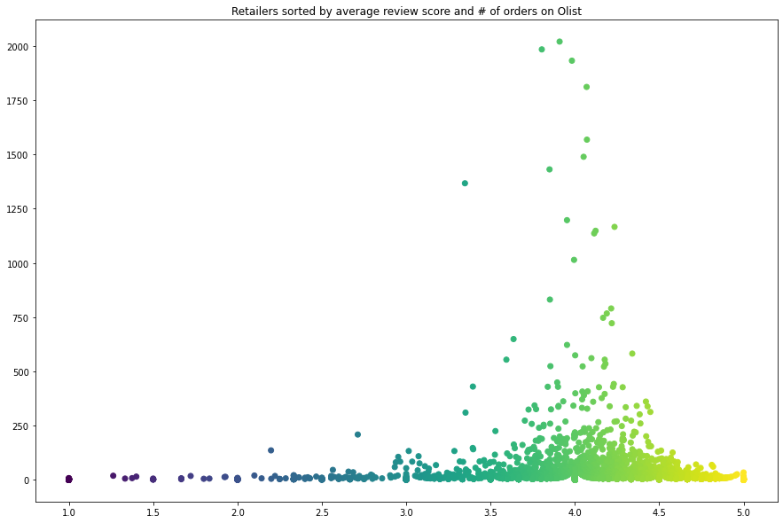

```python
# Graph showing the sellers, how many orders there are for that seller and what average review score they have

plt.figure(figsize=(15,10))
plt.title('Retailers sorted by average review score and # of orders on Olist')
plt.scatter(data=cost_reviews_df, y='count_orders', x='average_score', c='average_score')
```

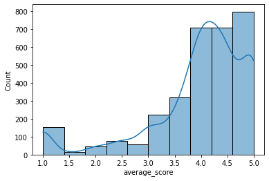

```python
sns.histplot(data=cost_reviews_df['average_score'], kde=True, bins = 10)
```

==> While majority of sellers on Olist have a good average score, there's still a sizeable portion of seller with a average score <= 3, meaning they create costs for Olist.

### Calculating costs and profit per seller

Olist's revenue source is taking a 10% cut from sellers' sales + 80 BRL fee per month for being listed on Olist.

With this information we can calculate the revenue generated by each seller, cost from reviews profit per seller.

```python
seller_df = Seller().get_training_data().copy()

#Merging seller information with cost from reviews dataframe. Relevant is
seller_df = seller_df.merge(cost_reviews_df, on="seller_id", how="outer")
seller_df["revenues"] = seller_df["sales"]*0.1+80*seller_df["months_on_olist"]
seller_df.revenues = seller_df.revenues.fillna(0)
seller_df["profit"] = seller_df.revenues - seller_df.review_cost
```

```python
seller_df = seller_df.sort_values('profit', ascending=True).reset_index()
seller_df
```

|  | index | seller_id | date_first_sale | date_last_sale | months_on_olist | quantity | sales | review_score | review_cost | revenues | profit |
| --- | --- | --- | --- | --- | --- | --- | --- | --- | --- | --- | --- |
| 0 | 769 | 6560211a19b47992c3666cc44a7e94c0 | 2017-02-17 07:45:11 | 2018-08-29 09:25:12 | 18.0 | 2033.0 | 123304.83 | 3.909406 | 40120 | 13770.483 | -26349.517 |
| 1 | 453 | 1f50f920176fa81dab994f9023523100 | 2017-04-03 22:15:14 | 2018-08-28 03:45:18 | 17.0 | 1931.0 | 106939.21 | 3.982402 | 37490 | 12053.921 | -25436.079 |
| 2 | 1132 | 7c67e1448b00f6e969d365cea6b010ab | 2017-01-26 22:55:10 | 2018-08-08 03:10:34 | 18.0 | 1364.0 | 187923.89 | 3.348208 | 44290 | 20232.389 | -24057.611 |
| 3 | 2358 | 4a3ca9315b744ce9f8e9374361493884 | 2017-01-08 09:45:12 | 2018-08-27 11:04:18 | 20.0 | 1987.0 | 200472.92 | 3.803931 | 44620 | 21647.292 | -22972.708 |
| 4 | 1357 | cc419e0650a3c5ba77189a1882b7556a | 2017-02-02 17:10:21 | 2018-08-28 03:45:15 | 19.0 | 1775.0 | 104288.42 | 4.069575 | 31070 | 11948.842 | -19121.158 |
| ... | ... | ... | ... | ... | ... | ... | ... | ... | ... | ... | ... |
| 3085 | 9 | ccc4bbb5f32a6ab2b7066a4130f114e3 | 2017-01-07 14:00:13 | 2018-08-21 21:05:16 | 19.0 | 192.0 | 74004.62 | 4.282723 | 2300 | 8920.462 | 6620.462 |
| 3086 | 2151 | edb1ef5e36e0c8cd84eb3c9b003e486d | 2017-09-30 09:49:22 | 2018-08-20 19:30:10 | 11.0 | 175.0 | 79284.55 | 4.434286 | 1570 | 8808.455 | 7238.455 |
| 3087 | 67 | 7e93a43ef30c4f03f38b393420bc753a | 2016-10-08 03:19:09 | 2018-07-14 21:25:19 | 21.0 | 340.0 | 176431.87 | 4.206490 | 4840 | 19323.187 | 14483.187 |
| 3088 | 534 | fa1c13f2614d7b5c4749cbc52fecda94 | 2017-01-07 20:55:10 | 2018-08-29 10:04:16 | 20.0 | 586.0 | 194042.03 | 4.340206 | 6510 | 21004.203 | 14494.203 |
| 3089 | 868 | 53243585a1d6dc2643021fd1853d8905 | 2017-08-28 18:44:58 | 2018-08-21 16:35:26 | 12.0 | 410.0 | 222776.05 | 4.075980 | 6040 | 23237.605 | 17197.605 |

3090 rows × 11 columns

```python
len(seller_df[seller_df.profit <= 0])
```

```
615
```

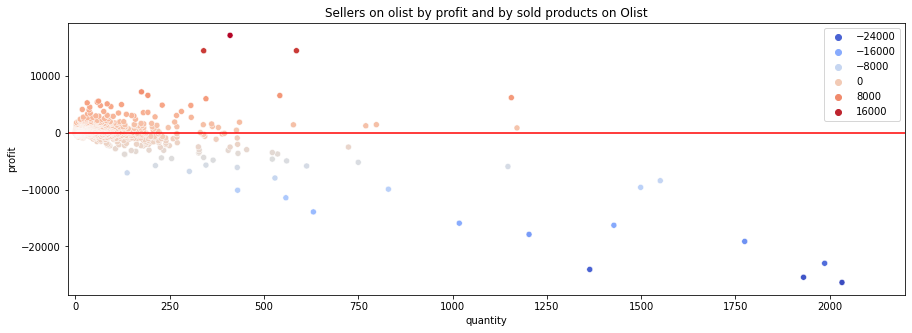

```python
plt.figure(figsize=(15,5))
plt.xlim([-20,2200])
plt.title('Sellers on olist by profit and by sold products on Olist')
sns.scatterplot(data=seller_df, x = 'quantity', y = 'profit', hue='profit', palette='coolwarm')
sns.lineplot(x=np.arange(-20,2500, 50), y=0, color='red')
```

The plot shows that we have some sellers on the platform which have a high amount of orders but are losing money for Olist, as the revenue they bring in is much less than the costs through negative reviews.

➡️ Removing sellers with negative profit will lead to improved profitability for Olist

### Let's calculate improved profitability for Olist when removing retailers with negative profit for Olist

```python
#Calculating revenue before removing non-profitable sellers
seller_df.revenues.sum()
```

```
2785818.444
```

```python
#Calculating revenue after removing non-profitable sellers
seller_df[seller_df.profit >= 0]['revenues'].sum()
```

```
2159188.605
```

Revenue will be reduced by -600K BRL, when removing non-profitable sellers.

```python
olist_profit_preremoval = np.sum(seller_df['profit'])
```

```python
olist_profit_postremoval = np.sum(seller_df[seller_df.profit >= 0]['profit'])
```

```python
olist_profit_postremoval - olist_profit_preremoval
```

```
548460.1610000001
```

However, by removing unprofitable sellers, profit would increase by 550K BRL.